# CS544 Homework 4

Phillip Escandon - escandon@bu.edu

16 February, 2021

[figure not shown]

## 1. Binomial Distribution - Perfect Score

```
Suppose a student has 40% chance of scoring a perfect score in an exam with randomly selected questions. Each student will be provided 5 attempts.
```

For the Binomial Distribution - look for an event that only has two outcomes - a success/ failure, 1/0, etc.

### a. Compute and plot the probability distribution

for the number of perfect scores over the 5 attempts. PMF and CDF

```r
# Probability of success
p <- .40
# number of attempts / trials
attempts <-5
# number of successes
successes <- 5

bi<-dbinom(successes,attempts,p)

# Probability Mass Function - shows the distribution of successes
x <- 0:attempts
paste('Probability of 5 perfect scores is',bi)
```

```
## [1] "Probability of 5 perfect scores is 0.01024"
```

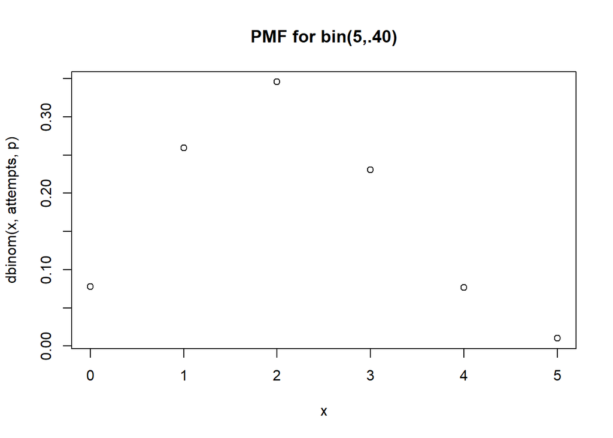

```r
plot(x,dbinom(x,attempts,p),main = "PMF for bin(5,.40)")
```

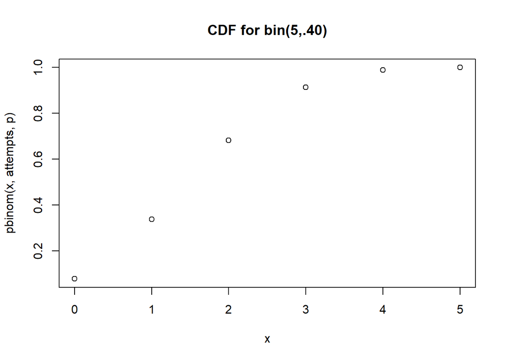

```r
plot(x,pbinom(x,attempts,p),main = "CDF for bin(5,.40)")
```

### b. Probability of exactly 2 perfect scores

```r
# Probability of success
p<- .40
# number of attempts / trials
attempts<-5
# number of successes
successes <- 2
bi2 <- dbinom(successes,attempts,p)

# Calculation by formula
# Equation: f(x) = {n x} p^x(1-p)^(n-x)
paste('Probability of exactly two perfect scores is ', bi2 )
```

```
## [1] "Probability of exactly two perfect scores is  0.3456"
```

$$f(x) = {n \choose x} p^{x} (1-p)^{n-x}$$
The manual calculation will use the above formula to verify the previous calculated probability

```r
# n = attempts
n <- 5
# p = Probability
p<- .4
# number of attempts / trials
x<- 2

# Binomial manual Calculation
fx <- choose(n,x)* (p**x) * ((1-p)**(n-x))

paste("f(2) is ",fx)
```

```
## [1] "f(2) is  0.3456"
```

### c. Probability of at least 2 perfect scores

```r
# P(X > 1)  at least 2 successes
# Same as  1 - P(X <= 1)
# 1 - pbinom(1, size = n, prob = p)
# or
# sum(dbinom(2:n, size = n, prob = p))


# Probability of success
p<- .40
# number of attempts / trial
attempts<- 5

# number of successes
successes <- 1


cdf<-1- pbinom(successes,attempts,p)
# check
# sum(dbinom(2:n, size = n, prob = p))

paste("Probability of at least 2 perfect scores is ",cdf)
```

```
## [1] "Probability of at least 2 perfect scores is  0.66304"
```

[figure not shown]

```r
x<- 0:attempts
# CDF Plot
plot(x,pbinom(x,attempts,p),type = "s",main = "CDF for Bin(2,.4)")
```

### d. Perfect scores for 1000 sutdents

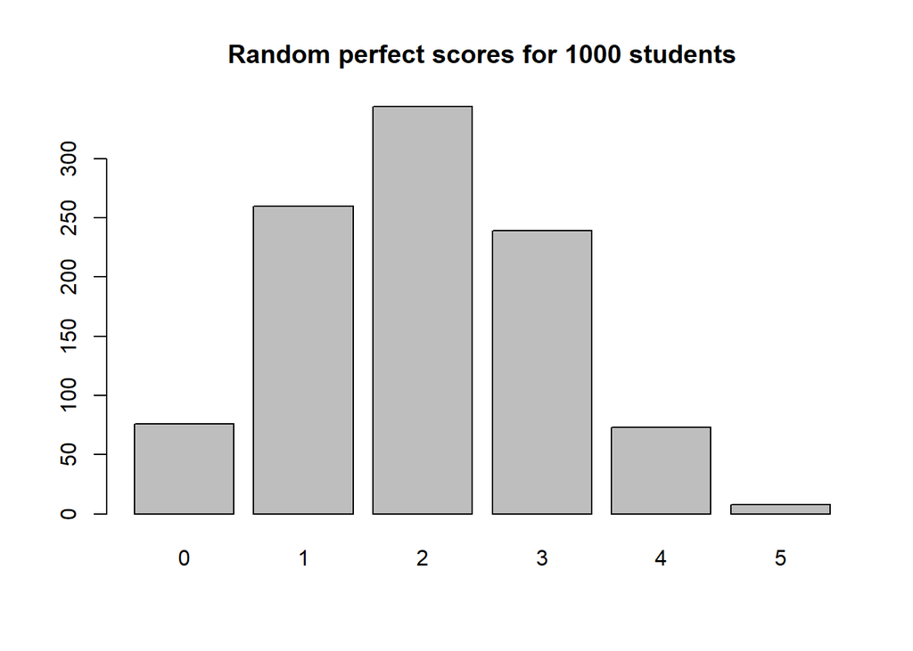

```r
# Probability of success
p<- .40
n<- 5
successes<- 5
# draw 1000 students
draws <- rbinom(1000,size = n, prob = p)
barplot(table(draws),main = "Random perfect scores for 1000 students")
```

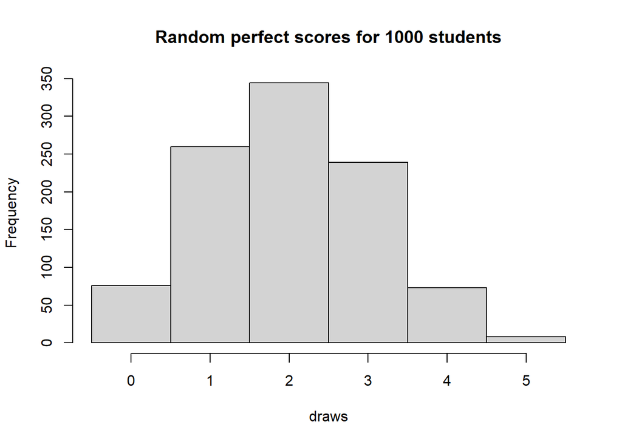

```
Question 2. Negative Binomial Distribution
```

```r
br<- (0:(n+1)) - .5
hist(draws,br,main = "Random perfect scores for 1000 students")
```

## 2. Negative Binomial Distibution -

Student has 60 percent chance of a perfect score. Suppose a student has 60% chance of scoring a perfect score in an exam with randomly selected questions. The student has to repeatedly take the exam until they achieve three perfect scores.

### a.

```r
# Need 3 perfect scores - will max 10 fails before quitting.
# Probability
p<- .60
# Number of success as 'r'
successes<- 3
# number of failures
fails <- 10
# this is the negative binomial distribution. failures before a success.

# args are usually (success, attempts, prob) this time..fails
(dnbinom(fails,successes,p))
```

```
## [1] 0.00149485
```

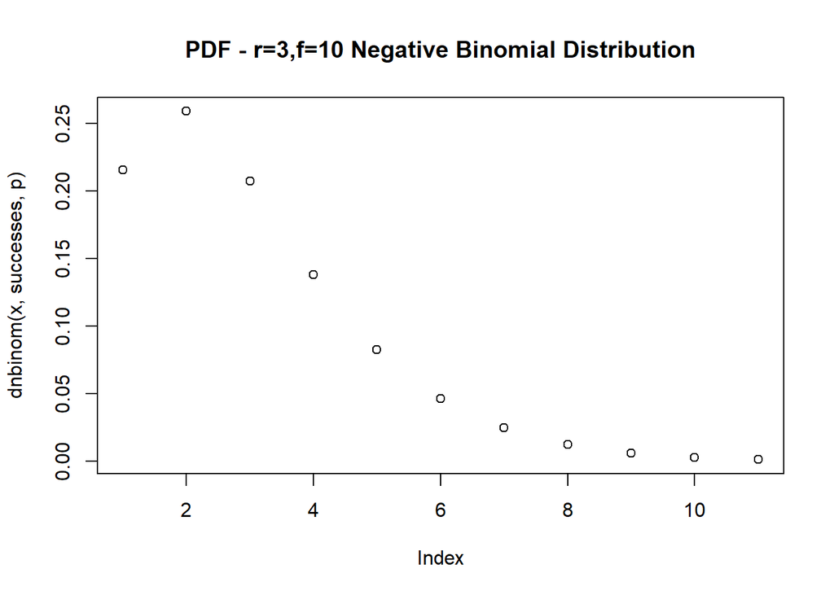

```r
x <- 0:fails
plot(dnbinom(x,successes,p),main = "PDF - r=3,f=10 Negative Binomial Distribution")
```

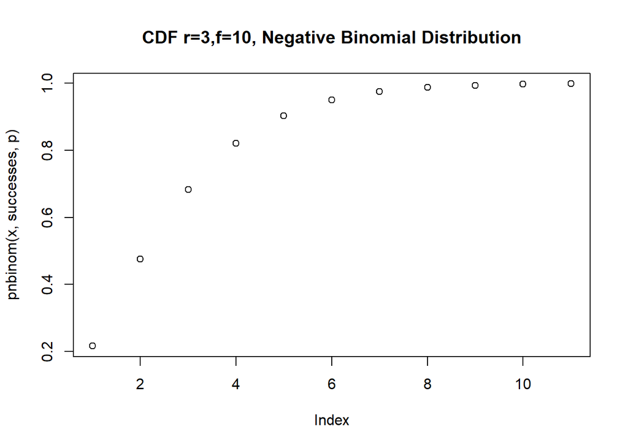

```r
plot(pnbinom(x,successes,p),main = "CDF r=3,f=10, Negative Binomial Distribution")
```

### b. What is the probability 3 perfect scores with exactly 4 failures

```r
successes <- 3
fails <- 4
p <- .6

dnb <- dnbinom(fails,successes,p)
paste('Probability of three perfect scores with 4 failures is',dnb)
```

```
## [1] "Probability of three perfect scores with 4 failures is 0.082944"
```

Perform the same calculation without the R function

$$f(4) = {6 \choose 2} (1-.6)^{4}.6^{3}$$

```r
# cannot get the example neg binomial by hand using matrix mult
# Left the args as r,x,p for a simplified choose equation

r <- 3 # successes
x <- 4 # fails
p <- .6
# f(4)
choose(6,2) * (.6**3) * ((1-.6)**4)
```

```
## [1] 0.082944
```

```r
choose((r+x)-1,r-1) * (p**r)* ((1-p)**x)
```

```
## [1] 0.082944
```

```r
#Check
#dnbinom(4,3,.6) == choose(6,2) * (.6**3) * ((1-p)**4)
```

### c. 3 Perfect scores with AT MOST 4 failures

```r
# Apply the CDF here
# P(X <= 4)   at most 4 failures
r <- 3
fails <- 4
p <- .6
cd <- pnbinom(fails,r,p)
paste('Probability of 3 Perfect scores with at most 4 failures:',cd)
```

```
## [1] "Probability of 3 Perfect scores with at most 4 failures: 0.903744"
```

### d. Simulate 3 perfect scores for 1000 students. Show a barplot

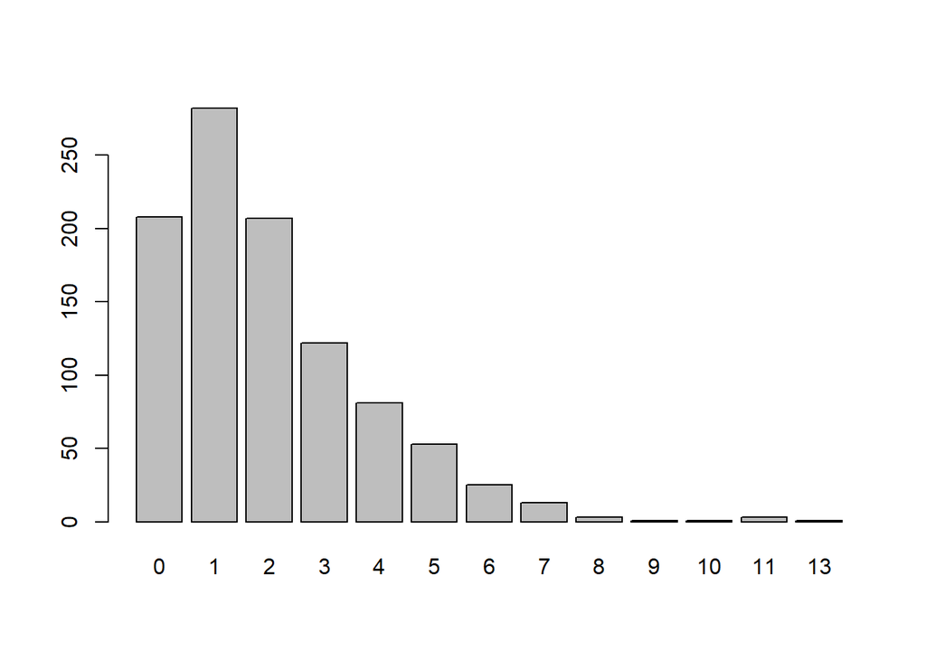

```
Question 3.
```

```r
r <- 3
fails <- 4
p <- .6
x <- rnbinom(1000, size = r, prob = p)
barplot(table(x))
```

## 3. Hypergeometric Distribution

```r
M <- 60    # Of interest
N <- 40    # Not of interest
K <- 20    # Sample Size
```

### a.

```r
M <- 60    # Of interest
N <- 40    # Not of interest
K <- 20    # Sample Size
dhyper(20, m = M, n = N, k = K)
```

```
## [1] 7.820848e-06
```

```r
pmf <-  dhyper(0:K,m=M,n=N,k=K)
pmf
```

```
##  [1] 2.571843e-10 1.469625e-08 3.744203e-07 5.665142e-06 5.718253e-05
##  [6] 4.098844e-04 2.167658e-03 8.670631e-03 2.666993e-02 6.376259e-02
## [11] 1.192361e-01 1.748329e-01 2.007847e-01 1.797234e-01 1.242206e-01
## [16] 6.530452e-02 2.550958e-02 7.137815e-03 1.346167e-03 1.526019e-04
## [21] 7.820848e-06
```

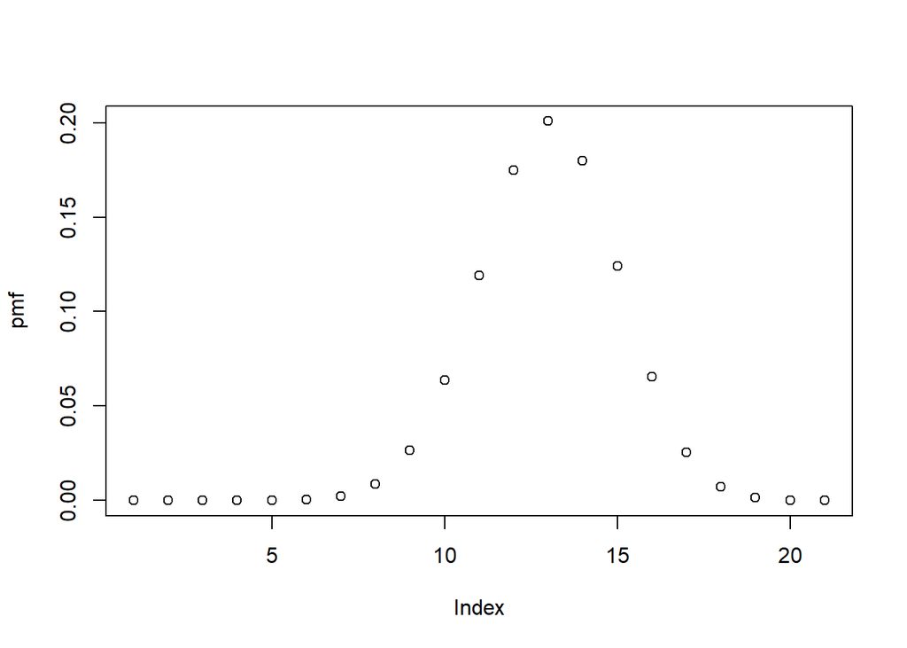

```r
plot(pmf)
```

### b. Exactly 10 multiple choice out of the 20

```r
# Review this portion - I don't know
M <- 60    # Of interest
N <- 40    # Not of interest
K <- 20    # Sample Size
phyper(10,m=M,n=N,k=K)
```

```
## [1] 0.22098
```

```r
cdf <-  phyper(0:K,m=M,n=N,k=K)
cdf
```

```
##  [1] 2.571843e-10 1.495343e-08 3.893737e-07 6.054516e-06 6.323704e-05
##  [6] 4.731214e-04 2.640779e-03 1.131141e-02 3.798134e-02 1.017439e-01
## [11] 2.209800e-01 3.958129e-01 5.965976e-01 7.763209e-01 9.005415e-01
## [16] 9.658460e-01 9.913556e-01 9.984934e-01 9.998396e-01 9.999922e-01
## [21] 1.000000e+00
```

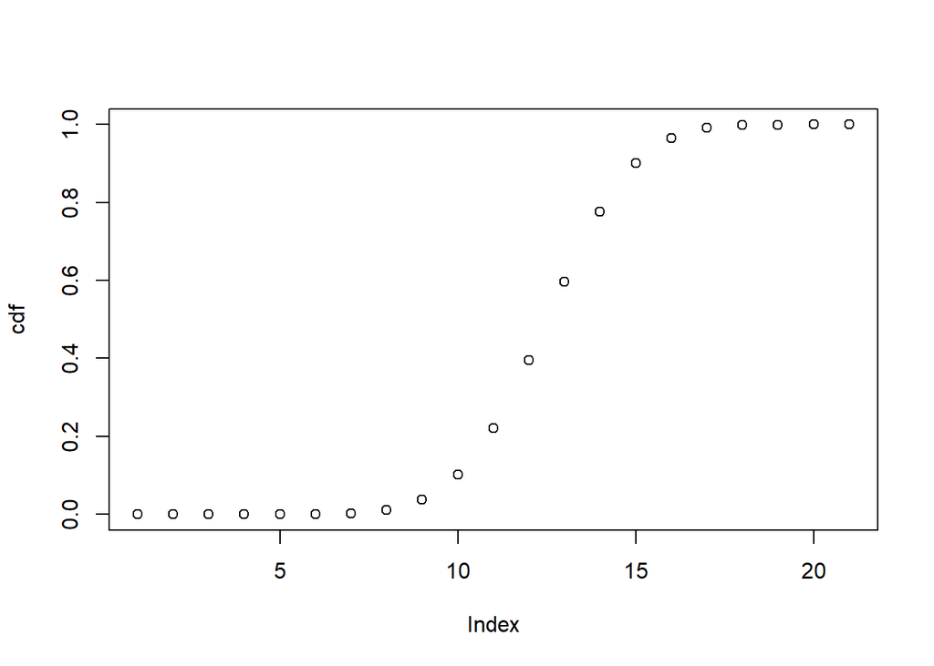

```r
plot(cdf)
```

```r
# P(X = 10)   10 questions of interest out of 20

a <- choose(M,10) * choose(N,10) / choose(M+N, 20)
paste("The probability that a student will have exactly 10 multiple choice quesions out of 20 is ",a)
```

```
## [1] "The probability that a student will have exactly 10 multiple choice quesions out of 20 is  0.11923605235456"
```

```r
# P(X > 2)   at least 3 faulty chips

1 - phyper(2, m = M, n = N, k = K)
```

```
## [1] 0.9999996
```

```r
# or
phyper(2, m = M, n = N, k = K, lower.tail = FALSE)
```

```
## [1] 0.9999996
```

### d.

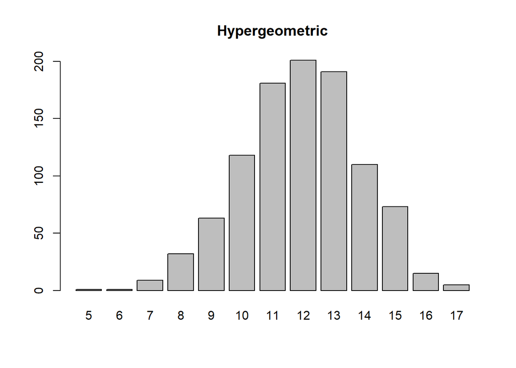

```
Question 4.
```

```r
x <- rhyper(1000, m = M, n = N, k = K )
barplot(table(x),main = 'Hypergeometric')
```

## 4. Poisson Distribution

```r
# On average 10 questions per day for prof
lmda <- 10
```

### a. Exactly 8 questions per day. Prob?

```r
dp <- dpois(8,lambda = lmda)
paste("Probability of exactly 8 questions per day : ",dp)
```

```
## [1] "Probability of exactly 8 questions per day :  0.11259903214902"
```

### b. At most 8 questions per day. Prob?

```r
pp <- ppois(8,lambda = lmda)
paste("Probability of at most 8 questions per day : ",pp)
```

```
## [1] "Probability of at most 8 questions per day :  0.332819678750719"
```

### c. 6 to 12 questions inclusive

```r
pinc <- ppois(12,lambda = lmda) - ppois(5,lambda = lmda)
paste("Probability of 6-12 questions inclusive is : ",pinc)
```

```
## [1] "Probability of 6-12 questions inclusive is :  0.724470513515842"
```

### d. PMF for the first 20 questions

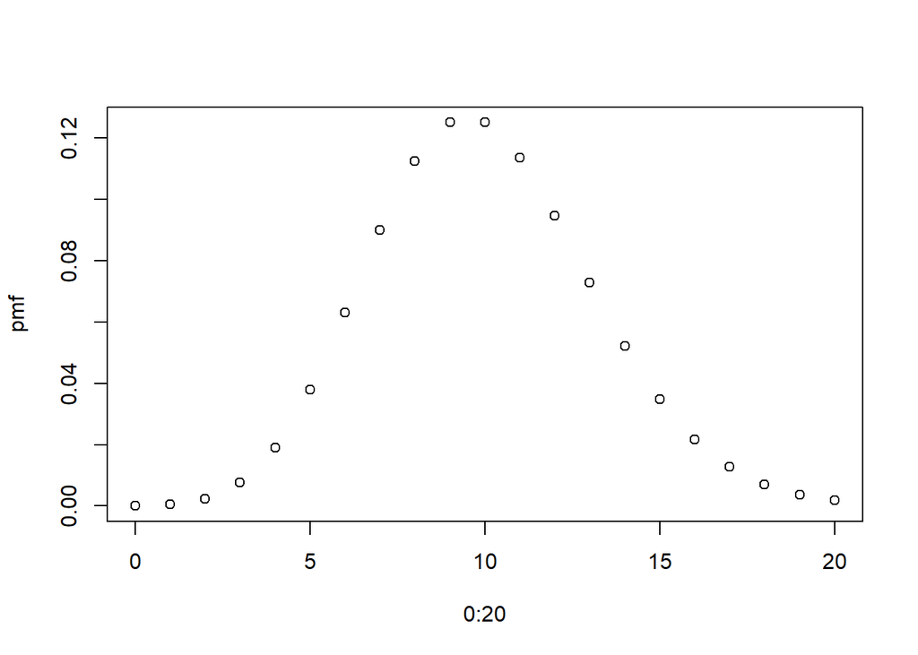

```r
pmf <-  dpois(0:20,lambda = lmda)
plot(0:20,pmf)
```